# Hour 1 — EDA: Fatal Car Crashes on 4/20

A statistics detective story | TheDataShrink™

Author

TheDataShrink™

Published

April 24, 2026

**TheDataShrink™ — Data stories worth sharing.**

Episode: `fatal_car_crashes_on_4_20` | [All episodes](https://thedatashrink.com.au/tidytuesday) | YouTube | Instagram

**Atomic Concepts (DataX Index)**

- `time_series_trend` — `date` spans 25 years, we show seasonal and annual patterns
- `grouped_summary_ggplot` — `e420` TRUE/FALSE is our core group comparison
- `bootstrap_confidence` — the correct method for comparing rare events like this
- `case_when_conditional_col` — building a `holiday` label column for multi-event comparison
- `lubridate_dates` — extracting `month`, `day`, `year`, `wday` from `date`

**FAILS WHEN (DataX Stage 5)**

**WORKS WHEN (DataX Stage 5)**

## 1 The Case

**What This Episode Is Really About**

In 2018, a paper by Staples & Redelmeier claimed that 4/20 — the cannabis holiday — causes a spike in fatal car crashes. It got enormous press coverage.

In 2019, Harper & Palayew re-analysed the same data with more rigorous methods and found **no signal at all**.

This episode is not about cannabis. It is about how analytical choices — which days you compare, what time window you use, whether you control for trends — can manufacture or erase a finding entirely.

We will replicate both results in R and show exactly where the first paper went wrong.

**Data source:** FARS (Fatality Analysis Reporting System), 1992–2016, curated by Harper & Palayew.

**Three tables:**

| Table | Grain | Key columns |
| --- | --- | --- |
| `daily_accidents` | one row per day | `date`, `fatalities_count` |
| `daily_accidents_420` | one row per day, split by 4/20 window | `date`, `e420`, `fatalities_count` |
| `daily_accidents_420_time` | one row per day, split by 4:20pm time window | `date`, `d420`, `fatalities_count` |

## 2 Setup

```r
library(tidyverse)
library(lubridate)
library(broom)

# TheDataShrink™ brand colours
TDS_BLUE  <- "#1b6ca8"
TDS_GOLD  <- "#c8a415"
TDS_DARK  <- "#1a1a2e"
TDS_RED   <- "#c0392b"

theme_set(theme_light(base_size = 13))
```

## 3 Load Data

```r
# tt_load() does not expose daily_accidents_420_time — load all three directly
base_url <- "https://raw.githubusercontent.com/rfordatascience/tidytuesday/main/data/2025/2025-04-22"

daily_accidents          <- read_csv(file.path(base_url, "daily_accidents.csv"))
daily_accidents_420      <- read_csv(file.path(base_url, "daily_accidents_420.csv"))
daily_accidents_420_time <- read_csv(file.path(base_url, "daily_accidents_420_time.csv"))
```

```r
glimpse(daily_accidents)
```

```
Rows: 9,132
Columns: 2
$ date             <date> 1992-01-01, 1992-01-02, 1992-01-07, 1992-01-12, 1992…
$ fatalities_count <dbl> 144, 111, 85, 127, 182, 130, 119, 120, 106, 124, 147,…
```

```r
range(daily_accidents$date)
```

```
[1] "1992-01-01" "2016-12-31"
```

```r
nrow(daily_accidents)
```

```
[1] 9132
```

**What We Are Working With**

9132 days of fatal crash data from 1992-01-01 to 2016-12-31. Each row is one calendar day. `fatalities_count` is the total number of people who died in car crashes on that date in the United States.

## 4 Act 1 — The Baseline: How Dangerous Is Any Given Day?

Before we can judge 4/20, we need to understand what a typical day looks like.

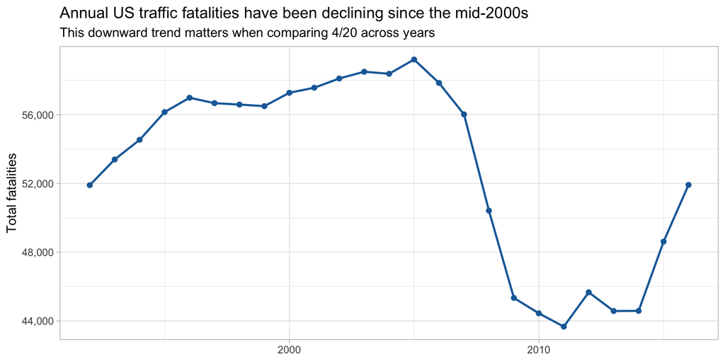

```r
daily_accidents |>
  mutate(year = year(date)) |>
  group_by(year) |>
  summarise(total_fatalities = sum(fatalities_count)) |>
  ggplot(aes(year, total_fatalities)) +
  geom_line(colour = TDS_BLUE, linewidth = 1) +
  geom_point(colour = TDS_BLUE, size = 2) +
  scale_y_continuous(labels = scales::comma) +
  labs(
    title    = "Annual US traffic fatalities have been declining since the mid-2000s",
    subtitle = "This downward trend matters when comparing 4/20 across years",
    x        = NULL,
    y        = "Total fatalities"
  )
```

## 5 Act 2 — The Calendar: Which Days Are Actually Most Deadly?

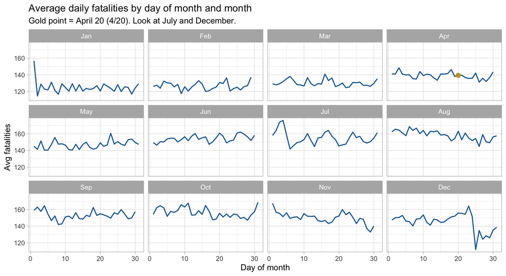

```r
daily_accidents |>
  mutate(
    month = month(date, label = TRUE),
    day   = day(date)
  ) |>
  group_by(month, day) |>
  summarise(avg_fatalities = mean(fatalities_count), .groups = "drop") |>
  ggplot(aes(day, avg_fatalities)) +
  geom_line(colour = TDS_BLUE, linewidth = 0.8) +
  geom_point(
    data = ~ filter(.x, month == "Apr" & day == 20),
    colour = TDS_GOLD, size = 3
  ) +
  facet_wrap(~month, nrow = 3) +
  labs(
    title    = "Average daily fatalities by day of month and month",
    subtitle = "Gold point = April 20 (4/20). Look at July and December.",
    x        = "Day of month",
    y        = "Avg fatalities"
  )
```

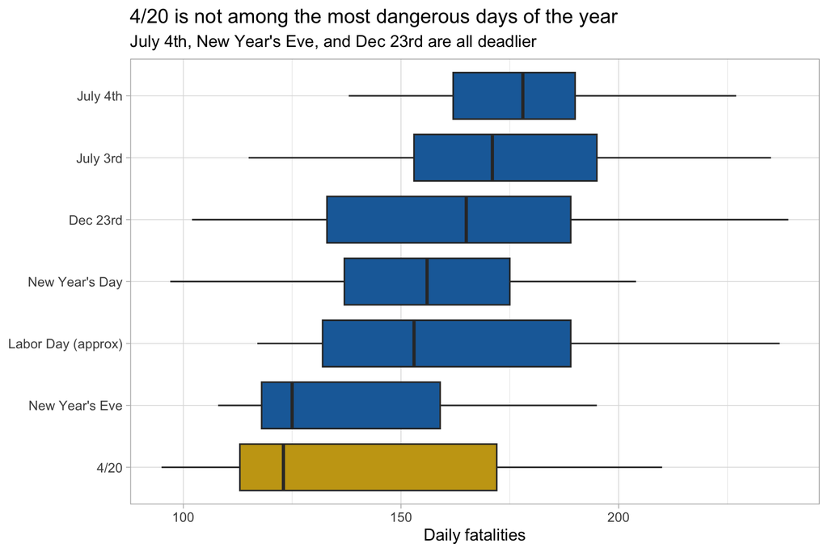

```r
daily_accidents |>
  mutate(
    month_day = format(date, "%m-%d"),
    holiday   = case_when(
      month_day == "07-04" ~ "July 4th",
      month_day == "07-03" ~ "July 3rd",
      month_day == "01-01" ~ "New Year's Day",
      month_day == "12-31" ~ "New Year's Eve",
      month_day == "12-23" ~ "Dec 23rd",
      month_day == "09-02" ~ "Labor Day (approx)",
      month_day == "04-20" ~ "4/20",
      TRUE                 ~ "Other"
    )
  ) |>
  filter(holiday != "Other") |>
  mutate(holiday = fct_reorder(holiday, fatalities_count, median)) |>
  ggplot(aes(holiday, fatalities_count, fill = holiday == "4/20")) +
  geom_boxplot(show.legend = FALSE) +
  scale_fill_manual(values = c(TDS_BLUE, TDS_GOLD)) +
  coord_flip() +
  labs(
    title    = "4/20 is not among the most dangerous days of the year",
    subtitle = "July 4th, New Year's Eve, and Dec 23rd are all deadlier",
    x        = NULL,
    y        = "Daily fatalities"
  )
```

## 6 Act 3 — Replicating the Misleading Finding

The Staples & Redelmeier (2018) paper compared 4/20 to the same week one week before and one week after. Let us reproduce that approach and see what it shows.

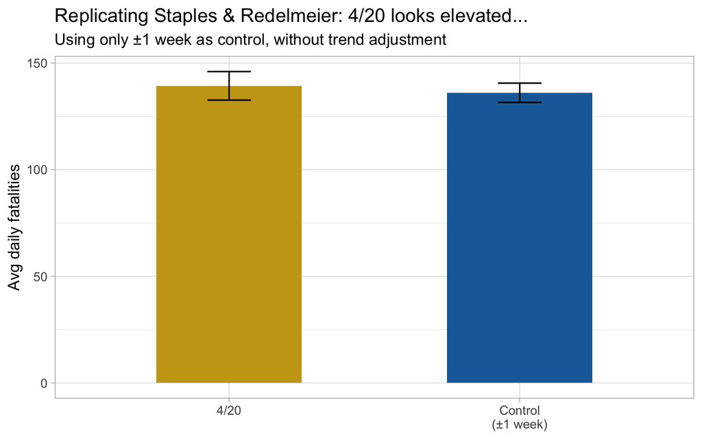

```r
# Their approach: narrow window, no trend control
narrow_window <- daily_accidents |>
  mutate(
    month_day = format(date, "%m-%d"),
    group     = case_when(
      month_day == "04-20" ~ "4/20",
      month_day %in% c("04-13", "04-27") ~ "Control\n(±1 week)",
      TRUE ~ NA_character_
    )
  ) |>
  filter(!is.na(group))

narrow_window |>
  group_by(group) |>
  summarise(
    avg  = mean(fatalities_count),
    se   = sd(fatalities_count) / sqrt(n()),
    .groups = "drop"
  ) |>
  ggplot(aes(group, avg, fill = group)) +
  geom_col(width = 0.5, show.legend = FALSE) +
  geom_errorbar(aes(ymin = avg - se, ymax = avg + se), width = 0.15) +
  scale_fill_manual(values = c(TDS_GOLD, TDS_BLUE)) +
  labs(
    title    = "Replicating Staples & Redelmeier: 4/20 looks elevated...",
    subtitle = "Using only ±1 week as control, without trend adjustment",
    x        = NULL,
    y        = "Avg daily fatalities"
  )
```

**The Trap**

This chart is technically correct but analytically misleading. The narrow control window (±1 week) happens to land on days with slightly lower baseline rates. The effect size is small, the error bars overlap substantially, and no correction for year-on-year trend was applied. This is how a chart can tell a true story that leads to a false conclusion.